# Homework10

Are reviewers motivated to post a review by negative experiences or positive ones?

I always assumed the majority of reviews come from frustrated customers seeking justice. Perhaps this is more of a reflection of my personal biases than the actual truth. So I looked through the Yelp reviews of restaurants local to Blacksburg to determine whether passionate reviews were more often positive or negative.

Positivity was defined using the Positive-Negative word count differences out of a positive and negative text dictionary. The difference was used instead of the ratio so that truly neutral reviews would start at 0, not 1.

Initial positive and negative word dictionaries provided in text files.

```python
import pandas
import numpy
import matplotlib
import matplotlib.pyplot as pp
%matplotlib inline

positives = set(open('positive.txt').read().split())
negatives = set(open('negative.txt').read().split())

data = pandas.read_csv('Homework10.csv')
data
```

|  | Restaurant | Author | Date | Stars | Text | Useful |
| --- | --- | --- | --- | --- | --- | --- |
| 0 | Cabo Fish Taco | Mark M. | 1/21/2019 | 5.0 | The tortilla chips were good, the salsa was re... | 2.0 |
| 1 | Cabo Fish Taco | K.P K. | 3/2/2019 | 4.0 | Nice variety of appetizers and entree's.Well s... | 0.0 |
| 2 | Cabo Fish Taco | Thomas N. | 12/23/2018 | 5.0 | Living in Blacksburg for the past 3 years I've... | 0.0 |
| 3 | Cabo Fish Taco | Miller G. | 12/22/2018 | 5.0 | This is easily my favorite restaurant in Black... | 0.0 |
| 4 | Cabo Fish Taco | Lori W. | 11/4/2018 | 5.0 | TACOS! there is A good reason "taco" is in the... | 0.0 |
| 5 | Cabo Fish Taco | Ruthvik K. | 3/23/2019 | 3.0 | The place seems a little overhyped. Ordered ch... | 0.0 |
| 6 | Cabo Fish Taco | Tyler C. | 10/10/2018 | 5.0 | I've lived in Blacksburg for close to 3 years ... | 0.0 |
| 7 | Cabo Fish Taco | Lorie F. | 7/20/2018 | 5.0 | A completely different taco dimension. I thoug... | 2.0 |
| 8 | Cabo Fish Taco | Greg O. | 2/6/2019 | 3.0 | It's amazing how much has changed in Blacksbur... | 0.0 |
| 9 | Cabo Fish Taco | Caroline F. | 11/24/2018 | 5.0 | Loved the complementary chips and corn salsa! ... | 0.0 |
| 10 | Cabo Fish Taco | Ellen P. | 3/24/2019 | 2.0 | The chips and shrimp were good but the blacken... | 0.0 |
| 11 | Cabo Fish Taco | Esther S. | 5/15/2018 | 5.0 | I come here every time I'm in Blacksburg! Too ... | 0.0 |
| 12 | Cabo Fish Taco | Chelsea C. | 1/17/2019 | 5.0 | Mmmmm so good!! Came in on a Wednesday night a... | 0.0 |
| 13 | Cabo Fish Taco | Erik G. | 3/13/2019 | 5.0 | Cabo was a great place for lunchtime tacos. We... | 0.0 |
| 14 | Cabo Fish Taco | Dorothy V. | 10/14/2018 | 5.0 | I've gone here more times than I can remember ... | 0.0 |
| 15 | Cabo Fish Taco | Meredith S. | 4/5/2018 | 5.0 | Wow! My son has lived in Blacksburg for the pa... | 0.0 |
| 16 | Cabo Fish Taco | William K. | 8/5/2018 | 5.0 | The Main Street was closed for an art fair, an... | 1.0 |
| 17 | Cabo Fish Taco | Devra S. | 12/19/2018 | 5.0 | Oh so delicious! Had the beer battered whitefi... | 0.0 |
| 18 | Cabo Fish Taco | Lexy P. | 2/24/2019 | 5.0 | Seriously this place deserves 6 stars. The foo... | 0.0 |
| 19 | Cabo Fish Taco | Steve S. | 2/10/2019 | 5.0 | Had lunch here for the first time on a Friday ... | 0.0 |
| 20 | Cabo Fish Taco | Kathryn T. | 1/25/2019 | 5.0 | Best food in Blacksburg--hands down. My go to'... | 0.0 |
| 21 | Cabo Fish Taco | Brandon B. | 4/15/2018 | 5.0 | I LOVE CABO. I went here dozens of times as an... | 0.0 |
| 22 | Cabo Fish Taco | Soo Y. | 9/9/2017 | 3.0 | Probably, I expected too much from the raved r... | 1.0 |
| 23 | Cabo Fish Taco | Kevin M. | 2/24/2018 | 5.0 | Loved it! My daughter and I were in town overn... | 2.0 |
| 24 | Cabo Fish Taco | Nikita T. | 6/4/2018 | 5.0 | I've only been to Cabo a few times, and it's a... | 0.0 |
| 25 | Cabo Fish Taco | Megan C. | 2/3/2019 | 4.0 | This is one of the most accredited restaurants... | 0.0 |
| 26 | Cabo Fish Taco | Emily S. | 1/24/2019 | 5.0 | The tacos here are absolutely out of this worl... | 0.0 |
| 27 | Cabo Fish Taco | Pat J. | 1/29/2019 | 4.0 | Their Honey Glazed Salmon Taco is my favorite.... | 0.0 |
| 28 | Cabo Fish Taco | Meaghan M. | 10/25/2018 | 5.0 | I love this place and I don't love seafood! Ye... | 0.0 |
| 29 | Cabo Fish Taco | Brittany K. | 9/14/2018 | 2.0 | Went to Cabo Taco around 8:00pm the other nigh... | 0.0 |
| ... | ... | ... | ... | ... | ... | ... |
| 1625 | Lefty’s Main Street Grille | W. L. | 5/6/2015 | 4.0 | I've only been to Lefty's for breakfast, but I... | 0.0 |
| 1626 | Lefty’s Main Street Grille | Davey B. | 7/23/2015 | 4.0 | My first meal in Blacksburg. Never been disapp... | 0.0 |
| 1627 | Lefty’s Main Street Grille | John D. | 9/5/2012 | 3.0 | Very cool place. The food is about on par with... | 0.0 |
| 1628 | Lefty’s Main Street Grille | Taran G. | 2/8/2015 | 5.0 | The breakfast and brunch is wonderful!! Love t... | 0.0 |
| 1629 | Lefty’s Main Street Grille | Deborah H. | 6/15/2010 | 4.0 | This is the best place we found in Blacksburg ... | 0.0 |
| 1630 | Lefty’s Main Street Grille | Lily M. | 4/10/2013 | 1.0 | Lefty's used to be one of my favorite restaura... | 0.0 |
| 1631 | Lefty’s Main Street Grille | Susan S. | 3/14/2013 | 1.0 | Had an early dinner there one night and I won'... | 0.0 |
| 1632 | Lefty’s Main Street Grille | Pete and Mel R. | 10/25/2009 | 4.0 | I think this place gets overlooked sometimes b... | 0.0 |
| 1633 | Lefty’s Main Street Grille | Dablackpurl K. | 4/28/2014 | 5.0 | nice cozy breakfast place. recently visited Le... | 0.0 |
| 1634 | Lefty’s Main Street Grille | Nino C. | 1/21/2014 | 1.0 | Second time in two week first time the burgher... | 0.0 |
| 1635 | Lefty’s Main Street Grille | Kellie H. | 6/30/2011 | 4.0 | I'm pretty sure this place used to be a Long J... | 0.0 |
| 1636 | Lefty’s Main Street Grille | Brett K. | 9/30/2011 | 5.0 | Much more than a standard burger place. Fresh ... | 0.0 |
| 1637 | Lefty’s Main Street Grille | Wes B. | 3/8/2009 | 5.0 | Lefty's makes the best burgers in town, hands ... | 0.0 |
| 1638 | Lefty’s Main Street Grille | David B. | 6/3/2013 | 5.0 | Excellent breakfast place with great service! ... | 0.0 |
| 1639 | Lefty’s Main Street Grille | Madeline H. | 12/14/2010 | 4.0 | Lefty's serves breakfast on Saturdays and Sund... | 0.0 |
| 1640 | Lefty’s Main Street Grille | John F. | 2/10/2012 | 1.0 | Despite the Buzz - TOTALLY DISAPPOINTINGWent o... | 0.0 |
| 1641 | Lefty’s Main Street Grille | Allen E. | 9/4/2011 | 1.0 | I've always heard good things about this place... | 0.0 |
| 1642 | Lefty’s Main Street Grille | Kevin O. | 8/3/2010 | 4.0 | Lefty's is easily passed by. It wasn't until r... | 0.0 |
| 1643 | Lefty’s Main Street Grille | Aaron B. | 3/5/2011 | 5.0 | Amazing food. Great beer. Good service. I have... | 0.0 |
| 1644 | Lefty’s Main Street Grille | Nick W. | 11/7/2009 | 5.0 | Note to aesthetic sticklers: this is not the b... | 4.0 |
| 1645 | Lefty’s Main Street Grille | Athena T. | 5/23/2008 | 5.0 | I have been a regular at Lefty's since 2004 an... | 0.0 |
| 1646 | Lefty’s Main Street Grille | Rich P. | 5/5/2010 | 4.0 | Service was very good. Calamari was very good,... | 0.0 |
| 1647 | Lefty’s Main Street Grille | Bernard W. | 2/28/2011 | 4.0 | My wife and I love Lefty's. We've been there s... | 0.0 |
| 1648 | Lefty’s Main Street Grille | Kristin P. | 10/16/2011 | 1.0 | Went here for breakfast on 10/9/2011 after vis... | 1.0 |
| 1649 | Lefty’s Main Street Grille | Sheena F. | 7/1/2010 | 4.0 | I know many people enjoy this place for their ... | 0.0 |
| 1650 | Lefty’s Main Street Grille | Danielle D. | 6/18/2012 | 4.0 | Best burgers in town! Highly recommend the Spi... | 0.0 |
| 1651 | Lefty’s Main Street Grille | Callie B. | 4/4/2009 | 4.0 | I'm a fan of eating outside on a beautiful day... | 1.0 |
| 1652 | Lefty’s Main Street Grille | Chris M. | 12/10/2011 | 4.0 | I like Lefty's for it's different selection of... | 0.0 |
| 1653 | Lefty’s Main Street Grille | Tina M. | 4/23/2010 | 4.0 | i'm glad we gave lefty's another shot after a ... | 0.0 |
| 1654 | Lefty’s Main Street Grille | Hungry H. | 5/6/2009 | 3.0 | Went for the first time last week. My Lefty bu... | 0.0 |

1655 rows × 6 columns

The text is significantly easier to organize once it has all been joined together.

```python
text = ' '.join(data.Text)
text = text.replace(',', '').replace('.', '')
text
```

```
'The tortilla chips were good the salsa was really good I ordered the Guacamole Salmon Salad and it was so good I almost ate the plate that came with it The salmon was cooked flawlessly not overcooked and dry like most places and the veggies were very fresh! The dressing was amazing!Shout out to Lin…
```

Text length is defined by how many words are present, the fundamental building block. This was found by coutning the split-ed strings in all collected text.

```python
data['Text Length'] = data.Text.str.split().str.len()
#p = len([w for w in tuple(data.Text.str.split().str) if w in positives])
#n = len([w for w in bag if w in negatives])

data['Positive Count'] = data.Text.str.split().map(lambda b: len([w for w in b if w in positives]))
data['Negative Count'] = data.Text.str.split().map(lambda b: len([w for w in b if w in negatives]))
data['PN Difference'] = data['Positive Count'] - data['Negative Count']
data
```

|  | Restaurant | Author | Date | Stars | Text | Useful | Text Length | Positive Count | Negative Count | PN Difference |
| --- | --- | --- | --- | --- | --- | --- | --- | --- | --- | --- |
| 0 | Cabo Fish Taco | Mark M. | 1/21/2019 | 5.0 | The tortilla chips were good, the salsa was re... | 2.0 | 80 | 3 | 0 | 3 |
| 1 | Cabo Fish Taco | K.P K. | 3/2/2019 | 4.0 | Nice variety of appetizers and entree's.Well s... | 0.0 | 51 | 5 | 0 | 5 |
| 2 | Cabo Fish Taco | Thomas N. | 12/23/2018 | 5.0 | Living in Blacksburg for the past 3 years I've... | 0.0 | 195 | 12 | 0 | 12 |
| 3 | Cabo Fish Taco | Miller G. | 12/22/2018 | 5.0 | This is easily my favorite restaurant in Black... | 0.0 | 159 | 11 | 0 | 11 |
| 4 | Cabo Fish Taco | Lori W. | 11/4/2018 | 5.0 | TACOS! there is A good reason "taco" is in the... | 0.0 | 156 | 12 | 2 | 10 |
| 5 | Cabo Fish Taco | Ruthvik K. | 3/23/2019 | 3.0 | The place seems a little overhyped. Ordered ch... | 0.0 | 35 | 3 | 2 | 1 |
| 6 | Cabo Fish Taco | Tyler C. | 10/10/2018 | 5.0 | I've lived in Blacksburg for close to 3 years ... | 0.0 | 247 | 12 | 5 | 7 |
| 7 | Cabo Fish Taco | Lorie F. | 7/20/2018 | 5.0 | A completely different taco dimension. I thoug... | 2.0 | 150 | 4 | 4 | 0 |
| 8 | Cabo Fish Taco | Greg O. | 2/6/2019 | 3.0 | It's amazing how much has changed in Blacksbur... | 0.0 | 95 | 5 | 1 | 4 |
| 9 | Cabo Fish Taco | Caroline F. | 11/24/2018 | 5.0 | Loved the complementary chips and corn salsa! ... | 0.0 | 89 | 5 | 0 | 5 |
| 10 | Cabo Fish Taco | Ellen P. | 3/24/2019 | 2.0 | The chips and shrimp were good but the blacken... | 0.0 | 48 | 3 | 1 | 2 |
| 11 | Cabo Fish Taco | Esther S. | 5/15/2018 | 5.0 | I come here every time I'm in Blacksburg! Too ... | 0.0 | 122 | 6 | 0 | 6 |
| 12 | Cabo Fish Taco | Chelsea C. | 1/17/2019 | 5.0 | Mmmmm so good!! Came in on a Wednesday night a... | 0.0 | 132 | 5 | 3 | 2 |
| 13 | Cabo Fish Taco | Erik G. | 3/13/2019 | 5.0 | Cabo was a great place for lunchtime tacos. We... | 0.0 | 122 | 8 | 1 | 7 |
| 14 | Cabo Fish Taco | Dorothy V. | 10/14/2018 | 5.0 | I've gone here more times than I can remember ... | 0.0 | 430 | 15 | 6 | 9 |
| 15 | Cabo Fish Taco | Meredith S. | 4/5/2018 | 5.0 | Wow! My son has lived in Blacksburg for the pa... | 0.0 | 276 | 16 | 0 | 16 |
| 16 | Cabo Fish Taco | William K. | 8/5/2018 | 5.0 | The Main Street was closed for an art fair, an... | 1.0 | 220 | 12 | 1 | 11 |
| 17 | Cabo Fish Taco | Devra S. | 12/19/2018 | 5.0 | Oh so delicious! Had the beer battered whitefi... | 0.0 | 71 | 5 | 3 | 2 |
| 18 | Cabo Fish Taco | Lexy P. | 2/24/2019 | 5.0 | Seriously this place deserves 6 stars. The foo... | 0.0 | 56 | 1 | 0 | 1 |
| 19 | Cabo Fish Taco | Steve S. | 2/10/2019 | 5.0 | Had lunch here for the first time on a Friday ... | 0.0 | 111 | 10 | 1 | 9 |
| 20 | Cabo Fish Taco | Kathryn T. | 1/25/2019 | 5.0 | Best food in Blacksburg--hands down. My go to'... | 0.0 | 45 | 0 | 1 | -1 |
| 21 | Cabo Fish Taco | Brandon B. | 4/15/2018 | 5.0 | I LOVE CABO. I went here dozens of times as an... | 0.0 | 157 | 11 | 2 | 9 |
| 22 | Cabo Fish Taco | Soo Y. | 9/9/2017 | 3.0 | Probably, I expected too much from the raved r... | 1.0 | 345 | 11 | 6 | 5 |
| 23 | Cabo Fish Taco | Kevin M. | 2/24/2018 | 5.0 | Loved it! My daughter and I were in town overn... | 2.0 | 79 | 4 | 1 | 3 |
| 24 | Cabo Fish Taco | Nikita T. | 6/4/2018 | 5.0 | I've only been to Cabo a few times, and it's a... | 0.0 | 107 | 5 | 0 | 5 |
| 25 | Cabo Fish Taco | Megan C. | 2/3/2019 | 4.0 | This is one of the most accredited restaurants... | 0.0 | 77 | 4 | 1 | 3 |
| 26 | Cabo Fish Taco | Emily S. | 1/24/2019 | 5.0 | The tacos here are absolutely out of this worl... | 0.0 | 35 | 3 | 0 | 3 |
| 27 | Cabo Fish Taco | Pat J. | 1/29/2019 | 4.0 | Their Honey Glazed Salmon Taco is my favorite.... | 0.0 | 44 | 2 | 0 | 2 |
| 28 | Cabo Fish Taco | Meaghan M. | 10/25/2018 | 5.0 | I love this place and I don't love seafood! Ye... | 0.0 | 87 | 4 | 0 | 4 |
| 29 | Cabo Fish Taco | Brittany K. | 9/14/2018 | 2.0 | Went to Cabo Taco around 8:00pm the other nigh... | 0.0 | 126 | 3 | 3 | 0 |
| ... | ... | ... | ... | ... | ... | ... | ... | ... | ... | ... |
| 1625 | Lefty’s Main Street Grille | W. L. | 5/6/2015 | 4.0 | I've only been to Lefty's for breakfast, but I... | 0.0 | 57 | 3 | 0 | 3 |
| 1626 | Lefty’s Main Street Grille | Davey B. | 7/23/2015 | 4.0 | My first meal in Blacksburg. Never been disapp... | 0.0 | 19 | 2 | 0 | 2 |
| 1627 | Lefty’s Main Street Grille | John D. | 9/5/2012 | 3.0 | Very cool place. The food is about on par with... | 0.0 | 40 | 2 | 1 | 1 |
| 1628 | Lefty’s Main Street Grille | Taran G. | 2/8/2015 | 5.0 | The breakfast and brunch is wonderful!! Love t... | 0.0 | 24 | 3 | 0 | 3 |
| 1629 | Lefty’s Main Street Grille | Deborah H. | 6/15/2010 | 4.0 | This is the best place we found in Blacksburg ... | 0.0 | 84 | 5 | 3 | 2 |
| 1630 | Lefty’s Main Street Grille | Lily M. | 4/10/2013 | 1.0 | Lefty's used to be one of my favorite restaura... | 0.0 | 110 | 3 | 4 | -1 |
| 1631 | Lefty’s Main Street Grille | Susan S. | 3/14/2013 | 1.0 | Had an early dinner there one night and I won'... | 0.0 | 30 | 2 | 0 | 2 |
| 1632 | Lefty’s Main Street Grille | Pete and Mel R. | 10/25/2009 | 4.0 | I think this place gets overlooked sometimes b... | 0.0 | 100 | 4 | 1 | 3 |
| 1633 | Lefty’s Main Street Grille | Dablackpurl K. | 4/28/2014 | 5.0 | nice cozy breakfast place. recently visited Le... | 0.0 | 59 | 8 | 1 | 7 |
| 1634 | Lefty’s Main Street Grille | Nino C. | 1/21/2014 | 1.0 | Second time in two week first time the burgher... | 0.0 | 44 | 2 | 0 | 2 |
| 1635 | Lefty’s Main Street Grille | Kellie H. | 6/30/2011 | 4.0 | I'm pretty sure this place used to be a Long J... | 0.0 | 154 | 6 | 5 | 1 |
| 1636 | Lefty’s Main Street Grille | Brett K. | 9/30/2011 | 5.0 | Much more than a standard burger place. Fresh ... | 0.0 | 46 | 3 | 0 | 3 |
| 1637 | Lefty’s Main Street Grille | Wes B. | 3/8/2009 | 5.0 | Lefty's makes the best burgers in town, hands ... | 0.0 | 67 | 4 | 0 | 4 |
| 1638 | Lefty’s Main Street Grille | David B. | 6/3/2013 | 5.0 | Excellent breakfast place with great service! ... | 0.0 | 28 | 3 | 0 | 3 |
| 1639 | Lefty’s Main Street Grille | Madeline H. | 12/14/2010 | 4.0 | Lefty's serves breakfast on Saturdays and Sund... | 0.0 | 98 | 4 | 1 | 3 |
| 1640 | Lefty’s Main Street Grille | John F. | 2/10/2012 | 1.0 | Despite the Buzz - TOTALLY DISAPPOINTINGWent o... | 0.0 | 106 | 1 | 1 | 0 |
| 1641 | Lefty’s Main Street Grille | Allen E. | 9/4/2011 | 1.0 | I've always heard good things about this place... | 0.0 | 111 | 4 | 4 | 0 |
| 1642 | Lefty’s Main Street Grille | Kevin O. | 8/3/2010 | 4.0 | Lefty's is easily passed by. It wasn't until r... | 0.0 | 95 | 6 | 0 | 6 |
| 1643 | Lefty’s Main Street Grille | Aaron B. | 3/5/2011 | 5.0 | Amazing food. Great beer. Good service. I have... | 0.0 | 50 | 4 | 0 | 4 |
| 1644 | Lefty’s Main Street Grille | Nick W. | 11/7/2009 | 5.0 | Note to aesthetic sticklers: this is not the b... | 4.0 | 142 | 9 | 1 | 8 |
| 1645 | Lefty’s Main Street Grille | Athena T. | 5/23/2008 | 5.0 | I have been a regular at Lefty's since 2004 an... | 0.0 | 134 | 5 | 3 | 2 |
| 1646 | Lefty’s Main Street Grille | Rich P. | 5/5/2010 | 4.0 | Service was very good. Calamari was very good,... | 0.0 | 23 | 1 | 0 | 1 |
| 1647 | Lefty’s Main Street Grille | Bernard W. | 2/28/2011 | 4.0 | My wife and I love Lefty's. We've been there s... | 0.0 | 69 | 2 | 1 | 1 |
| 1648 | Lefty’s Main Street Grille | Kristin P. | 10/16/2011 | 1.0 | Went here for breakfast on 10/9/2011 after vis... | 1.0 | 163 | 5 | 5 | 0 |
| 1649 | Lefty’s Main Street Grille | Sheena F. | 7/1/2010 | 4.0 | I know many people enjoy this place for their ... | 0.0 | 70 | 3 | 0 | 3 |
| 1650 | Lefty’s Main Street Grille | Danielle D. | 6/18/2012 | 4.0 | Best burgers in town! Highly recommend the Spi... | 0.0 | 26 | 0 | 0 | 0 |
| 1651 | Lefty’s Main Street Grille | Callie B. | 4/4/2009 | 4.0 | I'm a fan of eating outside on a beautiful day... | 1.0 | 85 | 2 | 0 | 2 |
| 1652 | Lefty’s Main Street Grille | Chris M. | 12/10/2011 | 4.0 | I like Lefty's for it's different selection of... | 0.0 | 51 | 2 | 0 | 2 |
| 1653 | Lefty’s Main Street Grille | Tina M. | 4/23/2010 | 4.0 | i'm glad we gave lefty's another shot after a ... | 0.0 | 73 | 7 | 1 | 6 |
| 1654 | Lefty’s Main Street Grille | Hungry H. | 5/6/2009 | 3.0 | Went for the first time last week. My Lefty bu... | 0.0 | 29 | 2 | 0 | 2 |

1655 rows × 10 columns

A cursory glance at word counts allows a simple prediction: higher PN difference among Blacksburg restaurants. Histograms plotting the positive and negative word counts show this is indeed the case, as there are far more positive words being used than negative in this dataset.

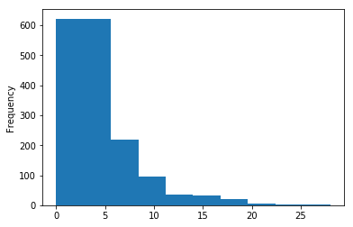

```python
data['Positive Count'].plot.hist()
```

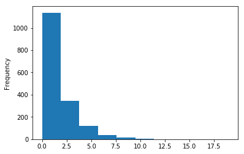

```python
data['Negative Count'].plot.hist()
```

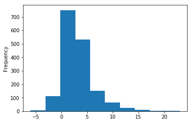

```python
data['PN Difference'].plot.hist()
```

To determine the accuracy of the word dictionaries, points were colored by Yelp's star rating system.

To determine whether passionate reviews were more often positive or negative from the restaurant customer's side (assumed to be reviews that take a larger amount of effort to write), text length PN Difference were graphed on the x and y axes respectively in a scatter plot. Passionate reviews on the restaurant customer's side are define text length.

To determine whether passionate reviews were more often positive or negative from the Yelp customer's side (assumed to be reviews that offer a critical perspective), points were sized by the handy Useful parameter, which is what Yelp customers define as passionate in this analysis.

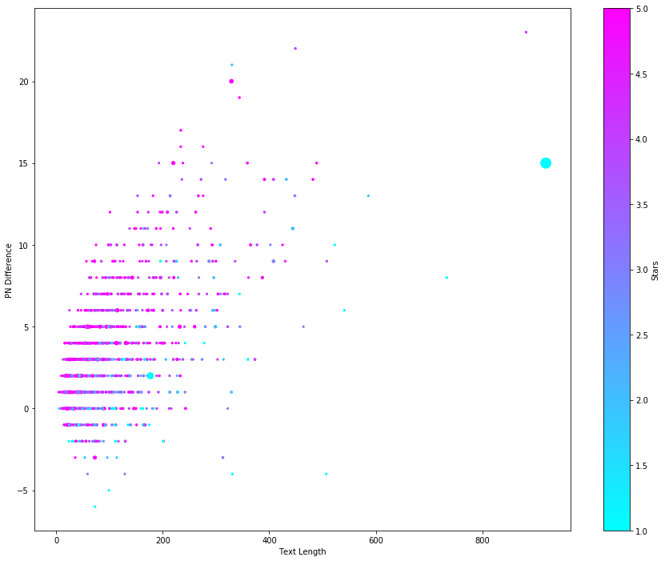

```python
sp = data.plot.scatter(x = 'Text Length', y = 'PN Difference', s = data.Useful + 1 * 5, c = 'Stars',
              colormap = pp.cm.cool , figsize = (15, 12), sharex = False)
sp;
```

If I wanted to continue my analysis, I would continue the analysis of the Useful metric and Star ratings with Yelp review data from other cities, such as my hometown of Richmond (a hidden foodie destination).